# 1 문제정의

### 1.1 문제 설명

- 제조사별 CO2배출량 확인 및 시각화
- 유종별 CO2배출량 확인 및 시각화
- 변속형식별 CO2배출량 확인 및 시각화
- 등급별 CO2배출량 확인 및 시각화

### 1.2 자료 수집처 https://www.data.go.kr/data/15005963/fileData.do

### 1.3 변수 설명

- 모델명 : 자동차 모델명
- 제조사 : 국내외 자동차 제조사
- 유종 : 자동차 유종
- 배기량 : 자동차 배기량
- 변속형식 : 자동차 변속기어형식
- 복합연비 : 도심연비와 고속도로주행 연비에 각각 55%, 45%의 가중치를 적용하여 산출된 연비
- 등급 : 복합연비를 기준으로 나눈 등급, 배기량에 상관없이 복합연비가 높은 차량에 높은 등급(1등급)을 부여하고 복합연비가 낮은 차량에는 낮은 등급(5등급)을 부여
- CO2배출량 : 자동차 이산화탄소 배출량

# 2 DataFrame 생성

```python
import pandas as pd
```

```python
data = pd.read_csv('C:/Users/CPB06GameN/Downloads/자동차 에너지소비효율등급 인증 현황_190903..csv', encoding = 'CP949')
data
```

|  | 모델명 | 제조사 | 유종 | 배기량 | 변속형식 | 복합연비 | 등급 | CO2배출량 |
| --- | --- | --- | --- | --- | --- | --- | --- | --- |
| 0 | 토요타 Prius AWD | 토요타 | 휘발유 | 1798 | 무단변속 | 20.9 | 1등급 | 74.0 |
| 1 | 코나 1.6GDI 하이브리드 (18" 타이어) | 현대 | 휘발유 | 1580 | 자동6 | 17.4 | 1등급 | 92.0 |
| 2 | 코나 1.6GDI 하이브리드 (16" 타이어) | 현대 | 휘발유 | 1580 | 자동6 | 19.3 | 1등급 | 82.0 |
| 3 | 코나 1.6디젤 2WD (16" 타이어) | 현대 | 경유 | 1598 | 자동7 | 17.5 | 1등급 | 105.0 |
| 4 | 코나 1.6디젤 2WD (17" 타이어) | 현대 | 경유 | 1598 | 자동7 | 17.3 | 1등급 | 107.0 |
| ... | ... | ... | ... | ... | ... | ... | ... | ... |
| 2082 | 넥쏘 수소전기차(19인치타이어) | 현대 | 수소 | 0 | 없음 | 93.7 | FCEV | 0.0 |
| 2083 | Danigo(다니고) | 대창모터스 | 전기 | 0 | 없음 | 5.3 | 저속 | 0.0 |
| 2084 | Change | AD 모터스 | 전기 | 0 | 없음 | 4.3 | 저속 | 0.0 |
| 2085 | 코나 전기자동차 (도심형) | 현대 | 전기 | 0 | 없음 | 5.8 | 고속 | 0.0 |
| 2086 | 아이오닉 전기차 (18MY) | 현대 | 전기 | 0 | 없음 | 6.3 | 고속 | 0.0 |

2087 rows × 8 columns

### 데이터 앞 행 6개

```python
data.head(6)
```

|  | 모델명 | 제조사 | 유종 | 배기량 | 변속형식 | 복합연비 | 등급 | CO2배출량 |
| --- | --- | --- | --- | --- | --- | --- | --- | --- |
| 0 | 토요타 Prius AWD | 토요타 | 휘발유 | 1798 | 무단변속 | 20.9 | 1등급 | 74.0 |
| 1 | 코나 1.6GDI 하이브리드 (18" 타이어) | 현대 | 휘발유 | 1580 | 자동6 | 17.4 | 1등급 | 92.0 |
| 2 | 코나 1.6GDI 하이브리드 (16" 타이어) | 현대 | 휘발유 | 1580 | 자동6 | 19.3 | 1등급 | 82.0 |
| 3 | 코나 1.6디젤 2WD (16" 타이어) | 현대 | 경유 | 1598 | 자동7 | 17.5 | 1등급 | 105.0 |
| 4 | 코나 1.6디젤 2WD (17" 타이어) | 현대 | 경유 | 1598 | 자동7 | 17.3 | 1등급 | 107.0 |
| 5 | 코나 1.6디젤 2WD (18" 타이어) | 현대 | 경유 | 1598 | 자동7 | 16.8 | 1등급 | 110.0 |

### 데이터 뒤 행 6개

```python
data.tail(6)
```

|  | 모델명 | 제조사 | 유종 | 배기량 | 변속형식 | 복합연비 | 등급 | CO2배출량 |
| --- | --- | --- | --- | --- | --- | --- | --- | --- |
| 2081 | 레이 전기차 | 기아 | 전기 | 0 | 없음 | 5.0 | 고속 | 0.0 |
| 2082 | 넥쏘 수소전기차(19인치타이어) | 현대 | 수소 | 0 | 없음 | 93.7 | FCEV | 0.0 |
| 2083 | Danigo(다니고) | 대창모터스 | 전기 | 0 | 없음 | 5.3 | 저속 | 0.0 |
| 2084 | Change | AD 모터스 | 전기 | 0 | 없음 | 4.3 | 저속 | 0.0 |
| 2085 | 코나 전기자동차 (도심형) | 현대 | 전기 | 0 | 없음 | 5.8 | 고속 | 0.0 |
| 2086 | 아이오닉 전기차 (18MY) | 현대 | 전기 | 0 | 없음 | 6.3 | 고속 | 0.0 |

### 데이터 행 / 열 개수

```python
data.shape
```

```
(2087, 8)
```

### 데이터 요약 정보

```python
data.info()
```

```
<class 'pandas.core.frame.DataFrame'>
RangeIndex: 2087 entries, 0 to 2086
Data columns (total 8 columns):
 #   Column  Non-Null Count  Dtype
---  ------  --------------  -----
 0   모델명     2087 non-null   object
 1   제조사     2087 non-null   object
 2   유종      2087 non-null   object
 3   배기량     2087 non-null   int64
 4   변속형식    2087 non-null   object
 5   복합연비    2087 non-null   float64
 6   등급      2087 non-null   object
 7   CO2배출량  2087 non-null   float64
dtypes: float64(2), int64(1), object(5)
memory usage: 130.6+ KB
```

```python
data.dtypes
```

```
모델명        object
제조사        object
유종         object
배기량         int64
변속형식       object
복합연비      float64
등급         object
CO2배출량    float64
dtype: object
```

### 컬럼에 관한 값 확인

```python
data['변속형식'].unique()
```

```
array(['무단변속', '자동6', '자동7', '자동8', '수동6', '자동9', '자동5', '자동4', '자동10',
       '수동5', '수동7', '없음'], dtype=object)
```

```python
data['CO2배출량'].unique()
```

```
array([ 74. ,  92. ,  82. , 105. , 107. , 110. ,  97. ,  83. ,  85. ,
        79. ,  80. , 113. , 116. , 109. ,  68. ,  95. , 104. , 108. ,
       106. ,  96. ,  93. , 111. , 114. , 115. ,  89. ,  94. ,  84. ,
       117. , 102. ,  88. ,  91. , 100. ,  71. ,  78. ,  69. , 112. ,
       103. , 121. , 120. , 134. , 132. , 130. , 119. , 129. , 123. ,
       135. , 131. , 127. , 122. , 101. , 124. , 128. , 133. , 118. ,
       126. , 125. , 138. , 137. , 136. , 139. , 143. , 141. , 142. ,
       144. , 183. , 152. , 165. , 147. , 156. , 140. , 146. , 145. ,
       151. , 161. , 162. , 153. , 163. , 157. , 149. , 158. , 154. ,
       150. , 164. , 155. , 160. , 167. , 148. , 159. , 166. , 168. ,
       173. , 170. , 172. , 189. , 198. , 186. , 220. , 169. , 178. ,
       185. , 171. , 177. , 201. , 184. , 181. , 188. , 180. , 182. ,
       196. , 202. , 206. , 174. , 176. , 179. , 175. , 194. , 193. ,
       205. , 195. , 187. , 208. , 197. , 204. , 207. , 200. , 199. ,
       210. , 203. , 192. , 190. , 212. , 216. , 211. , 214. , 248. ,
       247. , 277. , 234. , 245. , 331. , 233. , 218. , 246. , 228. ,
       250. , 226. , 275. , 215. , 276. , 405. , 213. , 240. , 191. ,
       398. , 224. , 244. , 267. , 281. , 260. , 217. , 241. , 263. ,
       239. , 262. , 319. , 223. , 408. , 295. , 264. , 227. , 237. ,
       221. , 251. , 283. , 278. , 307. , 302. , 294. , 298. , 222. ,
       238. , 309. , 219. , 231. , 229. , 315. , 242. , 279. , 280. ,
       310. , 325. , 243. , 225. , 316. , 318. , 320. , 230. , 235. ,
       232. , 266. , 236. , 268. , 253. , 265. , 271. , 252. , 286. ,
       311. , 317. , 259. , 258. , 289. , 313. , 301. , 274. , 346. ,
       291. , 254. , 255. , 285. , 303. , 306. , 342. , 270. , 257. ,
       209. , 249. , 350. , 273. , 522. , 328. , 359. , 297. ,   0. ,
        49. ,  63. ,  64. ,  17. ,  55. ,  67. ,  70. ,  54. ,  25. ,
        23. ,  89.8,  26. ,  42. ,  15. ,  29. ,  47. ,  99. ])
```

# 3 기술 통계 분석

```python
data['CO2배출량'].describe()
```

```
count    2087.000000
mean      168.493915
std        59.439791
min         0.000000
25%       138.000000
50%       166.000000
75%       201.500000
max       522.000000
Name: CO2배출량, dtype: float64
```

# 4 EDA

# CO2배출량 평균 박스플랏

```python
from matplotlib import pyplot as plt
import matplotlib.font_manager as fm
import matplotlib as mpl
mpl.rcParams['axes.unicode_minus'] = False
```

```python
plt.rcParams['axes.unicode_minus'] = False
plt.rcParams['font.family'] = 'NanumGothic'

# 설치된 폰트 출력
font_list = [font.name for font in fm.fontManager.ttflist]
font_list

plt.rcParams['font.family'] = 'New Gulim'
```

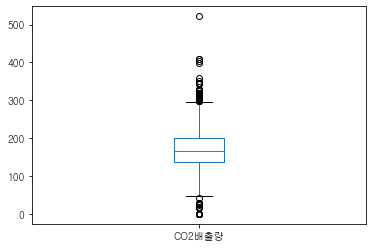

```python
data['CO2배출량'].plot(kind='box')
```

- 이상치가 존재하는것을 확인

# CO2배출량이 가장 높은 모델

```python
data[data['CO2배출량']==data['CO2배출량'].max()]
```

|  | 모델명 | 제조사 | 유종 | 배기량 | 변속형식 | 복합연비 | 등급 | CO2배출량 |
| --- | --- | --- | --- | --- | --- | --- | --- | --- |
| 1918 | Aventador LP700-4 | 람보르기니 | 휘발유 | 6498 | 자동7 | 4.5 | 5등급 | 522.0 |

- CO2배출량이 가장 높은 모델이 이상치인것으로 확인

# CO2배출량이 가장 낮은 모델

```python
data[data['CO2배출량']==data['CO2배출량'].min()]
```

|  | 모델명 | 제조사 | 유종 | 배기량 | 변속형식 | 복합연비 | 등급 | CO2배출량 |
| --- | --- | --- | --- | --- | --- | --- | --- | --- |
| 1933 | 넥쏘 수소전기차(17인치타이어) | 현대 | 수소 | 0 | 없음 | 96.2 | FCEV | 0.0 |
| 1934 | 넥쏘 수소전기차(19인치윈터타이어) | 현대 | 수소 | 0 | 없음 | 91.7 | FCEV | 0.0 |
| 2011 | 파워프라자 봉고3ev PEACE | 기아 | 전기 | 0 | 없음 | 2.4 | 고속 | 0.0 |
| 2012 | D2C | 쎄미시스코 | 전기 | 0 | 없음 | 5.2 | 고속 | 0.0 |
| 2013 | Model X Standard Range | 테슬라 | 전기 | 0 | 없음 | 3.8 | 고속 | 0.0 |
| ... | ... | ... | ... | ... | ... | ... | ... | ... |
| 2082 | 넥쏘 수소전기차(19인치타이어) | 현대 | 수소 | 0 | 없음 | 93.7 | FCEV | 0.0 |
| 2083 | Danigo(다니고) | 대창모터스 | 전기 | 0 | 없음 | 5.3 | 저속 | 0.0 |
| 2084 | Change | AD 모터스 | 전기 | 0 | 없음 | 4.3 | 저속 | 0.0 |
| 2085 | 코나 전기자동차 (도심형) | 현대 | 전기 | 0 | 없음 | 5.8 | 고속 | 0.0 |
| 2086 | 아이오닉 전기차 (18MY) | 현대 | 전기 | 0 | 없음 | 6.3 | 고속 | 0.0 |

78 rows × 8 columns

# C02배출량 중앙값

```python
data[data['CO2배출량']==data['CO2배출량'].median()]
```

|  | 모델명 | 제조사 | 유종 | 배기량 | 변속형식 | 복합연비 | 등급 | CO2배출량 |
| --- | --- | --- | --- | --- | --- | --- | --- | --- |
| 414 | BMW 730Ld xDrive WLTP | BMW | 경유 | 2993 | 자동8 | 11.6 | 3등급 | 166.0 |
| 415 | BMW 730d xDrive WLTP | BMW | 경유 | 2993 | 자동8 | 11.6 | 3등급 | 166.0 |
| 416 | BMW 740d xDrive WLTP | BMW | 경유 | 2993 | 자동8 | 11.6 | 3등급 | 166.0 |
| 494 | 재규어 F-PACE 25d | 재규어 | 경유 | 1999 | 자동8 | 11.6 | 3등급 | 166.0 |
| 556 | 쏘렌토 2.2디젤 4WD ISG 5인(18"타이어) (15) | 기아 | 경유 | 2199 | 자동6 | 11.6 | 3등급 | 166.0 |
| 560 | 쏘렌토 2.2디젤 4WD ISG 7인(18"타이어) (15) | 기아 | 경유 | 2199 | 자동6 | 11.6 | 3등급 | 166.0 |
| 628 | S350 d 4Matic | 벤츠 | 경유 | 2987 | 자동9 | 11.6 | 3등급 | 166.0 |
| 707 | 쏘렌토 2.2디젤 4WD ISG 5인(UM) | 기아 | 경유 | 2199 | 자동6 | 12.0 | 3등급 | 166.0 |
| 709 | 쏘렌토 2.2디젤 4WD ISG 7인(UM) | 기아 | 경유 | 2199 | 자동6 | 12.0 | 3등급 | 166.0 |
| 756 | A5 Coupe 45 TFSI quattro | 아우디 | 휘발유 | 1984 | 자동7 | 10.3 | 4등급 | 166.0 |
| 758 | A5 Coupe 45 TFSI quattro | 아우디 | 휘발유 | 1984 | 자동7 | 10.3 | 4등급 | 166.0 |
| 773 | 스팅어 2.0T-GDI 2WD_19인치타이어(올시즌) | 기아 | 휘발유 | 1998 | 자동8 | 10.3 | 4등급 | 166.0 |
| 838 | BMW X4 xDrive20d | BMW | 경유 | 1995 | 자동8 | 11.5 | 4등급 | 166.0 |
| 884 | K01H | DFSK | 휘발유 | 1240 | 수동5 | 10.1 | 4등급 | 166.0 |
| 1148 | 재규어 XF 25t | 재규어 | 휘발유 | 1999 | 자동8 | 10.1 | 4등급 | 166.0 |
| 1188 | 재규어 XE 2.0T | 재규어 | 휘발유 | 1999 | 자동8 | 10.3 | 4등급 | 166.0 |

```python
data['CO2배출량'].sort_values(ascending = False)
```

```
1918    522.0
1386    408.0
1385    408.0
1307    405.0
1327    398.0
        ...
1933      0.0
2032      0.0
2031      0.0
2030      0.0
2086      0.0
Name: CO2배출량, Length: 2087, dtype: float64
```

# 유종별 CO2배출량 막대그래프

```python
a = data.groupby('유종')[['CO2배출량']].mean()
a
```

| 유종 | CO2배출량 |
| --- | --- |
| LPG | 159.812500 |
| 경유 | 161.729114 |
| 수소 | 0.000000 |
| 전기 | 0.000000 |
| 전기+휘발유 | 53.475862 |
| 휘발유 | 188.367673 |

```python
import seaborn as sns
```

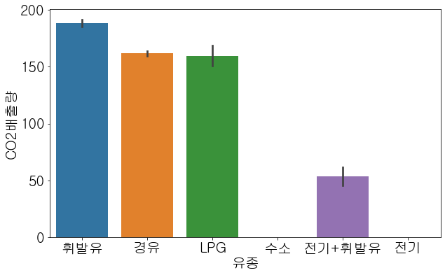

```python
sns.barplot(x="유종", y="CO2배출량", data=data)

plt.rcParams['figure.figsize'] = [10, 6]
plt.rc('font', size = 20)
```

- 유종별 CO2배출량을 봤을 때, 휘발유가 가장 높다는 것을 확인할 수 있다.
- 수소, 전기 차는 CO2배출량이 거의 없다고 볼 수 있다.

# 제조사별 CO2배출량

```python
b = data.groupby('제조사')[['CO2배출량']].mean()
b
```

| 제조사 | CO2배출량 |
| --- | --- |
| AD 모터스 | 0.000000 |
| BMW | 161.213613 |
| DFSK | 172.000000 |
| GM | 192.107143 |
| MINI | 135.222222 |
| PSA | 136.000000 |
| 기아 | 154.237164 |
| 닛산 | 166.733333 |
| 대창모터스 | 0.000000 |
| 람보르기니 | 336.636364 |
| 랜드로버 | 216.212121 |
| 롤스로이스 | 311.214286 |
| 르노삼성 | 133.648649 |
| 마제라티 | 238.736842 |
| 미쓰비시 | 201.312500 |
| 벤츠 | 190.552147 |
| 벤틀리 | 274.833333 |
| 볼보 | 145.086957 |
| 스바루 | 160.000000 |
| 쌍용 | 166.986486 |
| 쎄미시스코 | 0.000000 |
| 아우디 | 161.653846 |
| 어울림 | 232.000000 |
| 재규어 | 180.760563 |
| 제인모터스 | 0.000000 |
| 크라이슬러 | 194.492754 |
| 테슬라 | 0.000000 |
| 토요타 | 150.109375 |
| 파워테크닉스 | 0.000000 |
| 페라리 | 264.625000 |
| 포드 | 190.562500 |
| 포르쉐 | 215.648855 |
| 포톤 | 217.000000 |
| 폭스바겐 | 144.750000 |
| 푸조 | 137.333333 |
| 한국지엠 | 125.065217 |
| 현대 | 159.126904 |
| 혼다 | 141.000000 |

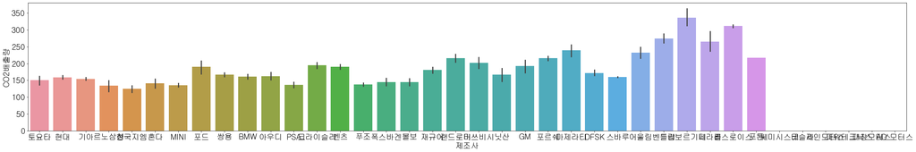

```python
sns.barplot(x="제조사", y="CO2배출량", data=data)

plt.rcParams['figure.figsize'] = [40, 6]
plt.rc('font', size = 20)
```

# 제조사별 CO2배출량 TOP5

```python
d = data.groupby('제조사')[['CO2배출량']].mean()
e = d.sort_values(by='CO2배출량', axis = 0, ascending = False).head()
e
```

| 제조사 | CO2배출량 |
| --- | --- |
| 람보르기니 | 336.636364 |
| 롤스로이스 | 311.214286 |
| 벤틀리 | 274.833333 |
| 페라리 | 264.625000 |
| 마제라티 | 238.736842 |

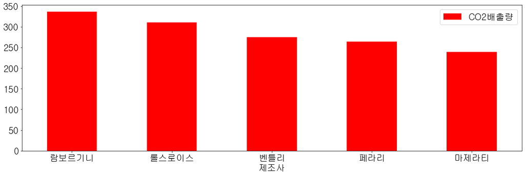

```python
e.plot(kind= 'bar', color = 'red')
plt.rcParams['figure.figsize'] = [20, 6]
plt.rc('font', size = 20)
plt.xticks(rotation = 0)
```

- 제조사별 CO2배출량이 많은순으로 TOP 5 를 봤을 때, 람보르기니, 롤스로이스, 벤틀리, 페라리, 마제라티 순으로 CO2배출량이 많은 것을 확인 할 수 있다.

# 변속형식별 CO2배출량

```python
g = data.groupby('변속형식')[['CO2배출량']].mean()
g
```

| 변속형식 | CO2배출량 |
| --- | --- |
| 무단변속 | 134.626984 |
| 수동5 | 133.521739 |
| 수동6 | 170.359223 |
| 수동7 | 203.500000 |
| 없음 | 0.000000 |
| 자동10 | 210.000000 |
| 자동4 | 151.636364 |
| 자동5 | 222.609375 |
| 자동6 | 154.845946 |
| 자동7 | 184.221910 |
| 자동8 | 184.439572 |
| 자동9 | 179.436364 |

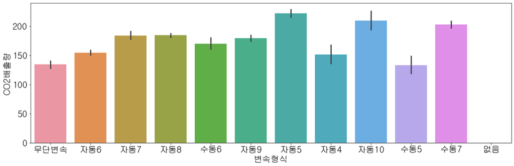

```python
sns.barplot(x="변속형식", y="CO2배출량", data=data)

plt.rcParams['figure.figsize'] = [20, 6]
plt.rc('font', size = 20)
```

- 자동5 변속기형식인 모델이 CO2배출량이 가장 많은것을 확인할 수 있고, 다음으로는 자동10, 수동7 변속기형식인 모델이 CO2배출량이 높게 나타나는것을 확인할 수 있다.

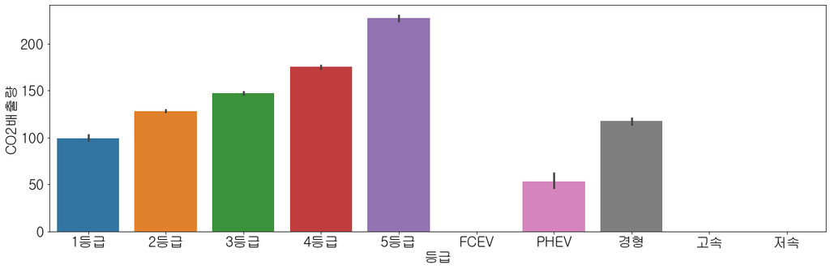

```python
sns.barplot(x="등급", y="CO2배출량", data=data)

plt.rcParams['figure.figsize'] = [20, 6]
plt.rc('font', size = 20)
```